# Risk Factor Analysis

## Outcome Variable

**Outcome Variable:** ever_stunted

## Predictor Variables

**Intervention Variable:** impsan

**Adjustment Set:**

unadjusted

## Stratifying Variables

The analysis was stratified on these variable(s):

- agecat
- studyid
- country

## Data Summary

| agecat | studyid | country | impsan | ever_stunted | n_cell | n | outcome_variable |
| --- | --- | --- | --- | --- | --- | --- | --- |
| 0-24 months (no birth st.) | ki0047075b-MAL-ED | BANGLADESH | 1 | 0 | 82 | 203 | ever_stunted |
| 0-24 months (no birth st.) | ki0047075b-MAL-ED | BANGLADESH | 1 | 1 | 88 | 203 | ever_stunted |
| 0-24 months (no birth st.) | ki0047075b-MAL-ED | BANGLADESH | 0 | 0 | 11 | 203 | ever_stunted |
| 0-24 months (no birth st.) | ki0047075b-MAL-ED | BANGLADESH | 0 | 1 | 22 | 203 | ever_stunted |
| 0-24 months (no birth st.) | ki0047075b-MAL-ED | BRAZIL | 1 | 0 | 151 | 185 | ever_stunted |
| 0-24 months (no birth st.) | ki0047075b-MAL-ED | BRAZIL | 1 | 1 | 30 | 185 | ever_stunted |
| 0-24 months (no birth st.) | ki0047075b-MAL-ED | BRAZIL | 0 | 0 | 3 | 185 | ever_stunted |
| 0-24 months (no birth st.) | ki0047075b-MAL-ED | BRAZIL | 0 | 1 | 1 | 185 | ever_stunted |
| 0-24 months (no birth st.) | ki0047075b-MAL-ED | INDIA | 1 | 0 | 44 | 196 | ever_stunted |
| 0-24 months (no birth st.) | ki0047075b-MAL-ED | INDIA | 1 | 1 | 44 | 196 | ever_stunted |
| 0-24 months (no birth st.) | ki0047075b-MAL-ED | INDIA | 0 | 0 | 45 | 196 | ever_stunted |
| 0-24 months (no birth st.) | ki0047075b-MAL-ED | INDIA | 0 | 1 | 63 | 196 | ever_stunted |
| 0-24 months (no birth st.) | ki0047075b-MAL-ED | NEPAL | 1 | 0 | 153 | 208 | ever_stunted |
| 0-24 months (no birth st.) | ki0047075b-MAL-ED | NEPAL | 1 | 1 | 54 | 208 | ever_stunted |
| 0-24 months (no birth st.) | ki0047075b-MAL-ED | NEPAL | 0 | 0 | 1 | 208 | ever_stunted |
| 0-24 months (no birth st.) | ki0047075b-MAL-ED | NEPAL | 0 | 1 | 0 | 208 | ever_stunted |
| 0-24 months (no birth st.) | ki0047075b-MAL-ED | PERU | 1 | 0 | 26 | 231 | ever_stunted |
| 0-24 months (no birth st.) | ki0047075b-MAL-ED | PERU | 1 | 1 | 31 | 231 | ever_stunted |
| 0-24 months (no birth st.) | ki0047075b-MAL-ED | PERU | 0 | 0 | 63 | 231 | ever_stunted |
| 0-24 months (no birth st.) | ki0047075b-MAL-ED | PERU | 0 | 1 | 111 | 231 | ever_stunted |
| 0-24 months (no birth st.) | ki0047075b-MAL-ED | SOUTH AFRICA | 1 | 0 | 3 | 225 | ever_stunted |
| 0-24 months (no birth st.) | ki0047075b-MAL-ED | SOUTH AFRICA | 1 | 1 | 1 | 225 | ever_stunted |
| 0-24 months (no birth st.) | ki0047075b-MAL-ED | SOUTH AFRICA | 0 | 0 | 93 | 225 | ever_stunted |
| 0-24 months (no birth st.) | ki0047075b-MAL-ED | SOUTH AFRICA | 0 | 1 | 128 | 225 | ever_stunted |
| 0-24 months (no birth st.) | ki0047075b-MAL-ED | TANZANIA, UNITED REPUBLIC OF | 1 | 0 | 0 | 202 | ever_stunted |
| 0-24 months (no birth st.) | ki0047075b-MAL-ED | TANZANIA, UNITED REPUBLIC OF | 1 | 1 | 0 | 202 | ever_stunted |
| 0-24 months (no birth st.) | ki0047075b-MAL-ED | TANZANIA, UNITED REPUBLIC OF | 0 | 0 | 30 | 202 | ever_stunted |
| 0-24 months (no birth st.) | ki0047075b-MAL-ED | TANZANIA, UNITED REPUBLIC OF | 0 | 1 | 172 | 202 | ever_stunted |
| 0-24 months (no birth st.) | ki1017093-NIH-Birth | BANGLADESH | 1 | 0 | 92 | 530 | ever_stunted |
| 0-24 months (no birth st.) | ki1017093-NIH-Birth | BANGLADESH | 1 | 1 | 111 | 530 | ever_stunted |

[output cut: 174 more lines]

The following strata were considered:

- agecat: 0-24 months (no birth st.), studyid: ki0047075b-MAL-ED, country: BANGLADESH
- agecat: 0-24 months (no birth st.), studyid: ki0047075b-MAL-ED, country: BRAZIL
- agecat: 0-24 months (no birth st.), studyid: ki0047075b-MAL-ED, country: INDIA
- agecat: 0-24 months (no birth st.), studyid: ki0047075b-MAL-ED, country: NEPAL
- agecat: 0-24 months (no birth st.), studyid: ki0047075b-MAL-ED, country: PERU
- agecat: 0-24 months (no birth st.), studyid: ki0047075b-MAL-ED, country: SOUTH AFRICA
- agecat: 0-24 months (no birth st.), studyid: ki0047075b-MAL-ED, country: TANZANIA, UNITED REPUBLIC OF
- agecat: 0-24 months (no birth st.), studyid: ki1017093-NIH-Birth, country: BANGLADESH
- agecat: 0-24 months (no birth st.), studyid: ki1017093b-PROVIDE, country: BANGLADESH
- agecat: 0-24 months (no birth st.), studyid: ki1017093c-NIH-Crypto, country: BANGLADESH
- agecat: 0-24 months (no birth st.), studyid: ki1114097-CONTENT, country: PERU
- agecat: 0-24 months (no birth st.), studyid: ki1135781-COHORTS, country: GUATEMALA
- agecat: 0-24 months (no birth st.), studyid: ki1135781-COHORTS, country: INDIA
- agecat: 0-24 months (no birth st.), studyid: ki1135781-COHORTS, country: PHILIPPINES
- agecat: 0-24 months (no birth st.), studyid: ki1148112-LCNI-5, country: MALAWI
- agecat: 0-24 months (no birth st.), studyid: kiGH5241-JiVitA-3, country: BANGLADESH
- agecat: 0-24 months (no birth st.), studyid: kiGH5241-JiVitA-4, country: BANGLADESH
- agecat: 0-6 months (no birth st.), studyid: ki0047075b-MAL-ED, country: BANGLADESH
- agecat: 0-6 months (no birth st.), studyid: ki0047075b-MAL-ED, country: BRAZIL
- agecat: 0-6 months (no birth st.), studyid: ki0047075b-MAL-ED, country: INDIA
- agecat: 0-6 months (no birth st.), studyid: ki0047075b-MAL-ED, country: NEPAL
- agecat: 0-6 months (no birth st.), studyid: ki0047075b-MAL-ED, country: PERU
- agecat: 0-6 months (no birth st.), studyid: ki0047075b-MAL-ED, country: SOUTH AFRICA
- agecat: 0-6 months (no birth st.), studyid: ki0047075b-MAL-ED, country: TANZANIA, UNITED REPUBLIC OF
- agecat: 0-6 months (no birth st.), studyid: ki1017093-NIH-Birth, country: BANGLADESH
- agecat: 0-6 months (no birth st.), studyid: ki1017093b-PROVIDE, country: BANGLADESH
- agecat: 0-6 months (no birth st.), studyid: ki1017093c-NIH-Crypto, country: BANGLADESH
- agecat: 0-6 months (no birth st.), studyid: ki1114097-CONTENT, country: PERU
- agecat: 0-6 months (no birth st.), studyid: ki1135781-COHORTS, country: GUATEMALA
- agecat: 0-6 months (no birth st.), studyid: ki1135781-COHORTS, country: INDIA
- agecat: 0-6 months (no birth st.), studyid: ki1135781-COHORTS, country: PHILIPPINES
- agecat: 0-6 months (no birth st.), studyid: ki1148112-LCNI-5, country: MALAWI
- agecat: 0-6 months (no birth st.), studyid: kiGH5241-JiVitA-3, country: BANGLADESH
- agecat: 0-6 months (no birth st.), studyid: kiGH5241-JiVitA-4, country: BANGLADESH
- agecat: 6-24 months, studyid: ki0047075b-MAL-ED, country: BANGLADESH
- agecat: 6-24 months, studyid: ki0047075b-MAL-ED, country: BRAZIL
- agecat: 6-24 months, studyid: ki0047075b-MAL-ED, country: INDIA
- agecat: 6-24 months, studyid: ki0047075b-MAL-ED, country: NEPAL
- agecat: 6-24 months, studyid: ki0047075b-MAL-ED, country: PERU
- agecat: 6-24 months, studyid: ki0047075b-MAL-ED, country: SOUTH AFRICA
- agecat: 6-24 months, studyid: ki0047075b-MAL-ED, country: TANZANIA, UNITED REPUBLIC OF
- agecat: 6-24 months, studyid: ki1017093-NIH-Birth, country: BANGLADESH
- agecat: 6-24 months, studyid: ki1017093b-PROVIDE, country: BANGLADESH
- agecat: 6-24 months, studyid: ki1017093c-NIH-Crypto, country: BANGLADESH
- agecat: 6-24 months, studyid: ki1114097-CONTENT, country: PERU
- agecat: 6-24 months, studyid: ki1135781-COHORTS, country: GUATEMALA
- agecat: 6-24 months, studyid: ki1135781-COHORTS, country: INDIA
- agecat: 6-24 months, studyid: ki1135781-COHORTS, country: PHILIPPINES
- agecat: 6-24 months, studyid: ki1148112-LCNI-5, country: MALAWI
- agecat: 6-24 months, studyid: kiGH5241-JiVitA-3, country: BANGLADESH
- agecat: 6-24 months, studyid: kiGH5241-JiVitA-4, country: BANGLADESH

### Dropped Strata

Some strata were dropped due to rare outcomes:

- agecat: 0-24 months (no birth st.), studyid: ki0047075b-MAL-ED, country: BRAZIL
- agecat: 0-24 months (no birth st.), studyid: ki0047075b-MAL-ED, country: NEPAL
- agecat: 0-24 months (no birth st.), studyid: ki0047075b-MAL-ED, country: SOUTH AFRICA
- agecat: 0-24 months (no birth st.), studyid: ki0047075b-MAL-ED, country: TANZANIA, UNITED REPUBLIC OF
- agecat: 0-24 months (no birth st.), studyid: ki1017093b-PROVIDE, country: BANGLADESH
- agecat: 0-24 months (no birth st.), studyid: ki1148112-LCNI-5, country: MALAWI
- agecat: 0-6 months (no birth st.), studyid: ki0047075b-MAL-ED, country: BRAZIL
- agecat: 0-6 months (no birth st.), studyid: ki0047075b-MAL-ED, country: NEPAL
- agecat: 0-6 months (no birth st.), studyid: ki0047075b-MAL-ED, country: SOUTH AFRICA
- agecat: 0-6 months (no birth st.), studyid: ki0047075b-MAL-ED, country: TANZANIA, UNITED REPUBLIC OF
- agecat: 0-6 months (no birth st.), studyid: ki1017093b-PROVIDE, country: BANGLADESH
- agecat: 0-6 months (no birth st.), studyid: ki1148112-LCNI-5, country: MALAWI
- agecat: 6-24 months, studyid: ki0047075b-MAL-ED, country: BRAZIL
- agecat: 6-24 months, studyid: ki0047075b-MAL-ED, country: NEPAL
- agecat: 6-24 months, studyid: ki0047075b-MAL-ED, country: SOUTH AFRICA
- agecat: 6-24 months, studyid: ki0047075b-MAL-ED, country: TANZANIA, UNITED REPUBLIC OF
- agecat: 6-24 months, studyid: ki1017093b-PROVIDE, country: BANGLADESH
- agecat: 6-24 months, studyid: ki1114097-CONTENT, country: PERU
- agecat: 6-24 months, studyid: ki1148112-LCNI-5, country: MALAWI

## Methods Detail

We’re interested in the causal parameters $E[Y_a]$ for all values of $a \in \mathcal{A}$. These parameters represent the mean outcome if, possibly contrary to fact, we intervened to set all units to have $A=a$. Under the randomization and positivity assumptions, these are identified by the statistical parameters $\psi_a=E_W[E_{Y|A,W}(Y|A=a,W)]$. In addition, we’re interested in the mean of $Y$, $E[Y]$ under no intervention (the observed mean). We will estimate these parameters by using SuperLearner to fit the relevant likelihood factors – $E_{Y|A,W}(Y|A=a,W)$ and $p(A=a|W)$, and then updating our likelihood fit using a joint TMLE.

For unadjusted analyses ($W=\{\}$), initial likelihoods were estimated using Lrnr_glm to estimate the simple $E(Y|A)$ and Lrnr_mean to estimate $p(A)$. For adjusted analyses, a small library containing Lrnr_glmnet, Lrnr_xgboost, and Lrnr_mean was used.

Having estimated these parameters, we will then use the delta method to estimate relative risks and attributable risks relative to a prespecified baseline level of $A$.

# Results Detail

## Results Plots

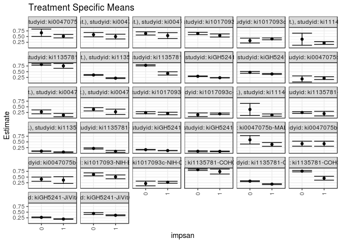

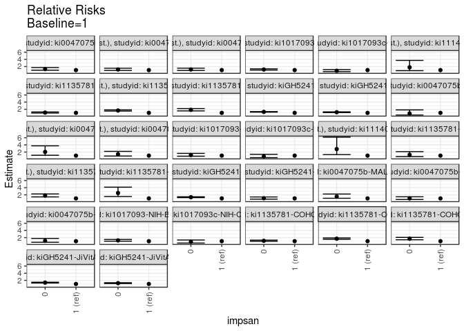

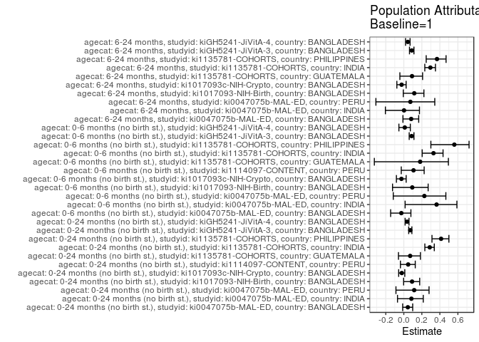

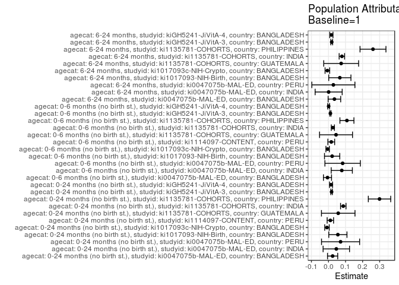

## Results Table

### Parameter: TSM

| agecat | studyid | country | intervention_level | baseline_level | estimate | ci_lower | ci_upper |
| --- | --- | --- | --- | --- | --- | --- | --- |
| 0-24 months (no birth st.) | ki0047075b-MAL-ED | BANGLADESH | 1 | NA | 0.5176471 | 0.4423470 | 0.5929471 |
| 0-24 months (no birth st.) | ki0047075b-MAL-ED | BANGLADESH | 0 | NA | 0.6666667 | 0.5054325 | 0.8279009 |
| 0-24 months (no birth st.) | ki0047075b-MAL-ED | INDIA | 1 | NA | 0.5000000 | 0.3952660 | 0.6047340 |
| 0-24 months (no birth st.) | ki0047075b-MAL-ED | INDIA | 0 | NA | 0.5833333 | 0.4901153 | 0.6765513 |
| 0-24 months (no birth st.) | ki0047075b-MAL-ED | PERU | 1 | NA | 0.5438596 | 0.4142774 | 0.6734419 |
| 0-24 months (no birth st.) | ki0047075b-MAL-ED | PERU | 0 | NA | 0.6379310 | 0.5663665 | 0.7094956 |
| 0-24 months (no birth st.) | ki1017093-NIH-Birth | BANGLADESH | 1 | NA | 0.5467980 | 0.4782540 | 0.6153420 |
| 0-24 months (no birth st.) | ki1017093-NIH-Birth | BANGLADESH | 0 | NA | 0.6360856 | 0.5838891 | 0.6882822 |
| 0-24 months (no birth st.) | ki1017093c-NIH-Crypto | BANGLADESH | 1 | NA | 0.4007030 | 0.3604070 | 0.4409990 |
| 0-24 months (no birth st.) | ki1017093c-NIH-Crypto | BANGLADESH | 0 | NA | 0.3243243 | 0.2175839 | 0.4310648 |
| 0-24 months (no birth st.) | ki1114097-CONTENT | PERU | 1 | NA | 0.2173913 | 0.1576413 | 0.2771413 |
| 0-24 months (no birth st.) | ki1114097-CONTENT | PERU | 0 | NA | 0.3846154 | 0.1194797 | 0.6497510 |
| 0-24 months (no birth st.) | ki1135781-COHORTS | GUATEMALA | 1 | NA | 0.7538462 | 0.6490420 | 0.8586503 |
| 0-24 months (no birth st.) | ki1135781-COHORTS | GUATEMALA | 0 | NA | 0.8175439 | 0.7858126 | 0.8492751 |
| 0-24 months (no birth st.) | ki1135781-COHORTS | INDIA | 1 | NA | 0.2146799 | 0.1957724 | 0.2335874 |
| 0-24 months (no birth st.) | ki1135781-COHORTS | INDIA | 0 | NA | 0.3554943 | 0.3380802 | 0.3729084 |
| 0-24 months (no birth st.) | ki1135781-COHORTS | PHILIPPINES | 1 | NA | 0.4237288 | 0.3508982 | 0.4965594 |
| 0-24 months (no birth st.) | ki1135781-COHORTS | PHILIPPINES | 0 | NA | 0.7793177 | 0.7527666 | 0.8058688 |
| 0-24 months (no birth st.) | kiGH5241-JiVitA-3 | BANGLADESH | 1 | NA | 0.2341917 | 0.2255257 | 0.2428576 |
| 0-24 months (no birth st.) | kiGH5241-JiVitA-3 | BANGLADESH | 0 | NA | 0.2980677 | 0.2844435 | 0.3116920 |
| 0-24 months (no birth st.) | kiGH5241-JiVitA-4 | BANGLADESH | 1 | NA | 0.3994093 | 0.3793062 | 0.4195123 |
| 0-24 months (no birth st.) | kiGH5241-JiVitA-4 | BANGLADESH | 0 | NA | 0.4698068 | 0.4321571 | 0.5074565 |
| 0-6 months (no birth st.) | ki0047075b-MAL-ED | BANGLADESH | 1 | NA | 0.2176471 | 0.1554638 | 0.2798304 |
| 0-6 months (no birth st.) | ki0047075b-MAL-ED | BANGLADESH | 0 | NA | 0.1818182 | 0.0498993 | 0.3137371 |
| 0-6 months (no birth st.) | ki0047075b-MAL-ED | INDIA | 1 | NA | 0.1363636 | 0.0644796 | 0.2082476 |
| 0-6 months (no birth st.) | ki0047075b-MAL-ED | INDIA | 0 | NA | 0.2777778 | 0.1930880 | 0.3624676 |
| 0-6 months (no birth st.) | ki0047075b-MAL-ED | PERU | 1 | NA | 0.2807018 | 0.1637976 | 0.3976059 |
| 0-6 months (no birth st.) | ki0047075b-MAL-ED | PERU | 0 | NA | 0.3908046 | 0.3181482 | 0.4634610 |
| 0-6 months (no birth st.) | ki1017093-NIH-Birth | BANGLADESH | 1 | NA | 0.2068966 | 0.1511200 | 0.2626731 |
| 0-6 months (no birth st.) | ki1017093-NIH-Birth | BANGLADESH | 0 | NA | 0.2415902 | 0.1951520 | 0.2880285 |
| 0-6 months (no birth st.) | ki1017093c-NIH-Crypto | BANGLADESH | 1 | NA | 0.1915641 | 0.1592040 | 0.2239242 |
| 0-6 months (no birth st.) | ki1017093c-NIH-Crypto | BANGLADESH | 0 | NA | 0.1486486 | 0.0675329 | 0.2297644 |
| 0-6 months (no birth st.) | ki1114097-CONTENT | PERU | 1 | NA | 0.1358696 | 0.0862338 | 0.1855054 |
| 0-6 months (no birth st.) | ki1114097-CONTENT | PERU | 0 | NA | 0.3846154 | 0.1194797 | 0.6497510 |
| 0-6 months (no birth st.) | ki1135781-COHORTS | GUATEMALA | 1 | NA | 0.2000000 | 0.0986982 | 0.3013018 |
| 0-6 months (no birth st.) | ki1135781-COHORTS | GUATEMALA | 0 | NA | 0.2495050 | 0.2117303 | 0.2872796 |
| 0-6 months (no birth st.) | ki1135781-COHORTS | INDIA | 1 | NA | 0.0525404 | 0.0420317 | 0.0630491 |
| 0-6 months (no birth st.) | ki1135781-COHORTS | INDIA | 0 | NA | 0.0941135 | 0.0833679 | 0.1048591 |
| 0-6 months (no birth st.) | ki1135781-COHORTS | PHILIPPINES | 1 | NA | 0.0847458 | 0.0436983 | 0.1257932 |
| 0-6 months (no birth st.) | ki1135781-COHORTS | PHILIPPINES | 0 | NA | 0.2132196 | 0.1869966 | 0.2394426 |
| 0-6 months (no birth st.) | kiGH5241-JiVitA-3 | BANGLADESH | 1 | NA | 0.1190804 | 0.1128981 | 0.1252626 |
| 0-6 months (no birth st.) | kiGH5241-JiVitA-3 | BANGLADESH | 0 | NA | 0.1587119 | 0.1479413 | 0.1694825 |
| 0-6 months (no birth st.) | kiGH5241-JiVitA-4 | BANGLADESH | 1 | NA | 0.0845217 | 0.0719541 | 0.0970894 |
| 0-6 months (no birth st.) | kiGH5241-JiVitA-4 | BANGLADESH | 0 | NA | 0.0889175 | 0.0658762 | 0.1119589 |
| 6-24 months | ki0047075b-MAL-ED | BANGLADESH | 1 | NA | 0.3893130 | 0.3055504 | 0.4730755 |
| 6-24 months | ki0047075b-MAL-ED | BANGLADESH | 0 | NA | 0.5925926 | 0.4066677 | 0.7785175 |
| 6-24 months | ki0047075b-MAL-ED | INDIA | 1 | NA | 0.4210526 | 0.3096889 | 0.5324163 |
| 6-24 months | ki0047075b-MAL-ED | INDIA | 0 | NA | 0.4230769 | 0.3130791 | 0.5330747 |
| 6-24 months | ki0047075b-MAL-ED | PERU | 1 | NA | 0.3658537 | 0.2179132 | 0.5137941 |
| 6-24 months | ki0047075b-MAL-ED | PERU | 0 | NA | 0.4056604 | 0.3118662 | 0.4994546 |
| 6-24 months | ki1017093-NIH-Birth | BANGLADESH | 1 | NA | 0.5073529 | 0.4232072 | 0.5914987 |
| 6-24 months | ki1017093-NIH-Birth | BANGLADESH | 0 | NA | 0.6172249 | 0.5512317 | 0.6832180 |
| 6-24 months | ki1017093c-NIH-Crypto | BANGLADESH | 1 | NA | 0.2704545 | 0.2289085 | 0.3120006 |
| 6-24 months | ki1017093c-NIH-Crypto | BANGLADESH | 0 | NA | 0.2166667 | 0.1123205 | 0.3210128 |
| 6-24 months | ki1135781-COHORTS | GUATEMALA | 1 | NA | 0.7419355 | 0.6329304 | 0.8509405 |
| 6-24 months | ki1135781-COHORTS | GUATEMALA | 0 | NA | 0.8244681 | 0.7930470 | 0.8558891 |
| 6-24 months | ki1135781-COHORTS | INDIA | 1 | NA | 0.1881491 | 0.1692140 | 0.2070841 |
| 6-24 months | ki1135781-COHORTS | INDIA | 0 | NA | 0.3185484 | 0.3002092 | 0.3368876 |
| 6-24 months | ki1135781-COHORTS | PHILIPPINES | 1 | NA | 0.4477612 | 0.3635164 | 0.5320060 |
| 6-24 months | ki1135781-COHORTS | PHILIPPINES | 0 | NA | 0.7585714 | 0.7268500 | 0.7902928 |
| 6-24 months | kiGH5241-JiVitA-3 | BANGLADESH | 1 | NA | 0.1971613 | 0.1867410 | 0.2075816 |
| 6-24 months | kiGH5241-JiVitA-3 | BANGLADESH | 0 | NA | 0.2702011 | 0.2522784 | 0.2881238 |
| 6-24 months | kiGH5241-JiVitA-4 | BANGLADESH | 1 | NA | 0.3615089 | 0.3410158 | 0.3820020 |
| 6-24 months | kiGH5241-JiVitA-4 | BANGLADESH | 0 | NA | 0.4404609 | 0.4007863 | 0.4801356 |

### Parameter: E(Y)

| agecat | studyid | country | intervention_level | baseline_level | estimate | ci_lower | ci_upper |
| --- | --- | --- | --- | --- | --- | --- | --- |
| 0-24 months (no birth st.) | ki0047075b-MAL-ED | BANGLADESH | NA | NA | 0.5418719 | 0.4731628 | 0.6105810 |
| 0-24 months (no birth st.) | ki0047075b-MAL-ED | INDIA | NA | NA | 0.5459184 | 0.4760370 | 0.6157998 |
| 0-24 months (no birth st.) | ki0047075b-MAL-ED | PERU | NA | NA | 0.6147186 | 0.5518243 | 0.6776129 |
| 0-24 months (no birth st.) | ki1017093-NIH-Birth | BANGLADESH | NA | NA | 0.6018868 | 0.5601729 | 0.6436007 |
| 0-24 months (no birth st.) | ki1017093c-NIH-Crypto | BANGLADESH | NA | NA | 0.3919129 | 0.3541506 | 0.4296752 |
| 0-24 months (no birth st.) | ki1114097-CONTENT | PERU | NA | NA | 0.2284264 | 0.1696529 | 0.2871999 |
| 0-24 months (no birth st.) | ki1135781-COHORTS | GUATEMALA | NA | NA | 0.8110236 | 0.7805500 | 0.8414972 |
| 0-24 months (no birth st.) | ki1135781-COHORTS | INDIA | NA | NA | 0.3013786 | 0.2882798 | 0.3144773 |
| 0-24 months (no birth st.) | ki1135781-COHORTS | PHILIPPINES | NA | NA | 0.7228700 | 0.6965868 | 0.7491531 |
| 0-24 months (no birth st.) | kiGH5241-JiVitA-3 | BANGLADESH | NA | NA | 0.2523838 | 0.2446469 | 0.2601207 |
| 0-24 months (no birth st.) | kiGH5241-JiVitA-4 | BANGLADESH | NA | NA | 0.4144516 | 0.3962595 | 0.4326437 |
| 0-6 months (no birth st.) | ki0047075b-MAL-ED | BANGLADESH | NA | NA | 0.2118227 | 0.1554757 | 0.2681696 |
| 0-6 months (no birth st.) | ki0047075b-MAL-ED | INDIA | NA | NA | 0.2142857 | 0.1566940 | 0.2718774 |
| 0-6 months (no birth st.) | ki0047075b-MAL-ED | PERU | NA | NA | 0.3636364 | 0.3014678 | 0.4258049 |
| 0-6 months (no birth st.) | ki1017093-NIH-Birth | BANGLADESH | NA | NA | 0.2283019 | 0.1925336 | 0.2640702 |
| 0-6 months (no birth st.) | ki1017093c-NIH-Crypto | BANGLADESH | NA | NA | 0.1866252 | 0.1564874 | 0.2167630 |
| 0-6 months (no birth st.) | ki1114097-CONTENT | PERU | NA | NA | 0.1522843 | 0.1019837 | 0.2025848 |
| 0-6 months (no birth st.) | ki1135781-COHORTS | GUATEMALA | NA | NA | 0.2442478 | 0.2087898 | 0.2797057 |
| 0-6 months (no birth st.) | ki1135781-COHORTS | INDIA | NA | NA | 0.0783541 | 0.0705612 | 0.0861470 |
| 0-6 months (no birth st.) | ki1135781-COHORTS | PHILIPPINES | NA | NA | 0.1928251 | 0.1696580 | 0.2159922 |
| 0-6 months (no birth st.) | kiGH5241-JiVitA-3 | BANGLADESH | NA | NA | 0.1303730 | 0.1247937 | 0.1359524 |
| 0-6 months (no birth st.) | kiGH5241-JiVitA-4 | BANGLADESH | NA | NA | 0.0854560 | 0.0740923 | 0.0968198 |
| 6-24 months | ki0047075b-MAL-ED | BANGLADESH | NA | NA | 0.4240506 | 0.3467471 | 0.5013542 |
| 6-24 months | ki0047075b-MAL-ED | INDIA | NA | NA | 0.4220779 | 0.3438191 | 0.5003367 |
| 6-24 months | ki0047075b-MAL-ED | PERU | NA | NA | 0.3945578 | 0.3152779 | 0.4738378 |
| 6-24 months | ki1017093-NIH-Birth | BANGLADESH | NA | NA | 0.5739130 | 0.5216565 | 0.6261696 |
| 6-24 months | ki1017093c-NIH-Crypto | BANGLADESH | NA | NA | 0.2640000 | 0.2253243 | 0.3026757 |
| 6-24 months | ki1135781-COHORTS | GUATEMALA | NA | NA | 0.8162939 | 0.7859345 | 0.8466533 |
| 6-24 months | ki1135781-COHORTS | INDIA | NA | NA | 0.2666991 | 0.2531888 | 0.2802093 |
| 6-24 months | ki1135781-COHORTS | PHILIPPINES | NA | NA | 0.7086331 | 0.6777759 | 0.7394903 |
| 6-24 months | kiGH5241-JiVitA-3 | BANGLADESH | NA | NA | 0.2162136 | 0.2068317 | 0.2255956 |
| 6-24 months | kiGH5241-JiVitA-4 | BANGLADESH | NA | NA | 0.3784303 | 0.3598372 | 0.3970234 |

### Parameter: RR

| agecat | studyid | country | intervention_level | baseline_level | estimate | ci_lower | ci_upper |
| --- | --- | --- | --- | --- | --- | --- | --- |
| 0-24 months (no birth st.) | ki0047075b-MAL-ED | BANGLADESH | 1 | 1 | 1.0000000 | 1.0000000 | 1.000000 |
| 0-24 months (no birth st.) | ki0047075b-MAL-ED | BANGLADESH | 0 | 1 | 1.2878788 | 0.9711920 | 1.707831 |
| 0-24 months (no birth st.) | ki0047075b-MAL-ED | INDIA | 1 | 1 | 1.0000000 | 1.0000000 | 1.000000 |
| 0-24 months (no birth st.) | ki0047075b-MAL-ED | INDIA | 0 | 1 | 1.1666667 | 0.8964490 | 1.518336 |
| 0-24 months (no birth st.) | ki0047075b-MAL-ED | PERU | 1 | 1 | 1.0000000 | 1.0000000 | 1.000000 |
| 0-24 months (no birth st.) | ki0047075b-MAL-ED | PERU | 0 | 1 | 1.1729700 | 0.9013932 | 1.526369 |
| 0-24 months (no birth st.) | ki1017093-NIH-Birth | BANGLADESH | 1 | 1 | 1.0000000 | 1.0000000 | 1.000000 |
| 0-24 months (no birth st.) | ki1017093-NIH-Birth | BANGLADESH | 0 | 1 | 1.1632917 | 1.0014294 | 1.351316 |
| 0-24 months (no birth st.) | ki1017093c-NIH-Crypto | BANGLADESH | 1 | 1 | 1.0000000 | 1.0000000 | 1.000000 |
| 0-24 months (no birth st.) | ki1017093c-NIH-Crypto | BANGLADESH | 0 | 1 | 0.8093883 | 0.5737199 | 1.141863 |
| 0-24 months (no birth st.) | ki1114097-CONTENT | PERU | 1 | 1 | 1.0000000 | 1.0000000 | 1.000000 |
| 0-24 months (no birth st.) | ki1114097-CONTENT | PERU | 0 | 1 | 1.7692308 | 0.8423327 | 3.716082 |
| 0-24 months (no birth st.) | ki1135781-COHORTS | GUATEMALA | 1 | 1 | 1.0000000 | 1.0000000 | 1.000000 |
| 0-24 months (no birth st.) | ki1135781-COHORTS | GUATEMALA | 0 | 1 | 1.0844970 | 0.9387315 | 1.252897 |
| 0-24 months (no birth st.) | ki1135781-COHORTS | INDIA | 1 | 1 | 1.0000000 | 1.0000000 | 1.000000 |
| 0-24 months (no birth st.) | ki1135781-COHORTS | INDIA | 0 | 1 | 1.6559273 | 1.4971780 | 1.831509 |
| 0-24 months (no birth st.) | ki1135781-COHORTS | PHILIPPINES | 1 | 1 | 1.0000000 | 1.0000000 | 1.000000 |
| 0-24 months (no birth st.) | ki1135781-COHORTS | PHILIPPINES | 0 | 1 | 1.8391898 | 1.5435746 | 2.191419 |
| 0-24 months (no birth st.) | kiGH5241-JiVitA-3 | BANGLADESH | 1 | 1 | 1.0000000 | 1.0000000 | 1.000000 |
| 0-24 months (no birth st.) | kiGH5241-JiVitA-3 | BANGLADESH | 0 | 1 | 1.2727511 | 1.2034540 | 1.346039 |
| 0-24 months (no birth st.) | kiGH5241-JiVitA-4 | BANGLADESH | 1 | 1 | 1.0000000 | 1.0000000 | 1.000000 |
| 0-24 months (no birth st.) | kiGH5241-JiVitA-4 | BANGLADESH | 0 | 1 | 1.1762541 | 1.0724446 | 1.290112 |
| 0-6 months (no birth st.) | ki0047075b-MAL-ED | BANGLADESH | 1 | 1 | 1.0000000 | 1.0000000 | 1.000000 |
| 0-6 months (no birth st.) | ki0047075b-MAL-ED | BANGLADESH | 0 | 1 | 0.8353808 | 0.3830278 | 1.821959 |
| 0-6 months (no birth st.) | ki0047075b-MAL-ED | INDIA | 1 | 1 | 1.0000000 | 1.0000000 | 1.000000 |
| 0-6 months (no birth st.) | ki0047075b-MAL-ED | INDIA | 0 | 1 | 2.0370370 | 1.1079703 | 3.745154 |
| 0-6 months (no birth st.) | ki0047075b-MAL-ED | PERU | 1 | 1 | 1.0000000 | 1.0000000 | 1.000000 |
| 0-6 months (no birth st.) | ki0047075b-MAL-ED | PERU | 0 | 1 | 1.3922414 | 0.8823480 | 2.196793 |
| 0-6 months (no birth st.) | ki1017093-NIH-Birth | BANGLADESH | 1 | 1 | 1.0000000 | 1.0000000 | 1.000000 |
| 0-6 months (no birth st.) | ki1017093-NIH-Birth | BANGLADESH | 0 | 1 | 1.1676860 | 0.8385569 | 1.625997 |
| 0-6 months (no birth st.) | ki1017093c-NIH-Crypto | BANGLADESH | 1 | 1 | 1.0000000 | 1.0000000 | 1.000000 |
| 0-6 months (no birth st.) | ki1017093c-NIH-Crypto | BANGLADESH | 0 | 1 | 0.7759732 | 0.4382904 | 1.373825 |
| 0-6 months (no birth st.) | ki1114097-CONTENT | PERU | 1 | 1 | 1.0000000 | 1.0000000 | 1.000000 |
| 0-6 months (no birth st.) | ki1114097-CONTENT | PERU | 0 | 1 | 2.8307692 | 1.2974209 | 6.176295 |
| 0-6 months (no birth st.) | ki1135781-COHORTS | GUATEMALA | 1 | 1 | 1.0000000 | 1.0000000 | 1.000000 |
| 0-6 months (no birth st.) | ki1135781-COHORTS | GUATEMALA | 0 | 1 | 1.2475248 | 0.7352899 | 2.116605 |
| 0-6 months (no birth st.) | ki1135781-COHORTS | INDIA | 1 | 1 | 1.0000000 | 1.0000000 | 1.000000 |
| 0-6 months (no birth st.) | ki1135781-COHORTS | INDIA | 0 | 1 | 1.7912591 | 1.4227799 | 2.255169 |
| 0-6 months (no birth st.) | ki1135781-COHORTS | PHILIPPINES | 1 | 1 | 1.0000000 | 1.0000000 | 1.000000 |
| 0-6 months (no birth st.) | ki1135781-COHORTS | PHILIPPINES | 0 | 1 | 2.5159907 | 1.5264379 | 4.147047 |
| 0-6 months (no birth st.) | kiGH5241-JiVitA-3 | BANGLADESH | 1 | 1 | 1.0000000 | 1.0000000 | 1.000000 |
| 0-6 months (no birth st.) | kiGH5241-JiVitA-3 | BANGLADESH | 0 | 1 | 1.3328135 | 1.2268292 | 1.447954 |
| 0-6 months (no birth st.) | kiGH5241-JiVitA-4 | BANGLADESH | 1 | 1 | 1.0000000 | 1.0000000 | 1.000000 |
| 0-6 months (no birth st.) | kiGH5241-JiVitA-4 | BANGLADESH | 0 | 1 | 1.0520078 | 0.7878939 | 1.404656 |
| 6-24 months | ki0047075b-MAL-ED | BANGLADESH | 1 | 1 | 1.0000000 | 1.0000000 | 1.000000 |
| 6-24 months | ki0047075b-MAL-ED | BANGLADESH | 0 | 1 | 1.5221496 | 1.0404884 | 2.226781 |
| 6-24 months | ki0047075b-MAL-ED | INDIA | 1 | 1 | 1.0000000 | 1.0000000 | 1.000000 |
| 6-24 months | ki0047075b-MAL-ED | INDIA | 0 | 1 | 1.0048077 | 0.6934450 | 1.455975 |
| 6-24 months | ki0047075b-MAL-ED | PERU | 1 | 1 | 1.0000000 | 1.0000000 | 1.000000 |
| 6-24 months | ki0047075b-MAL-ED | PERU | 0 | 1 | 1.1088050 | 0.6959182 | 1.766657 |
| 6-24 months | ki1017093-NIH-Birth | BANGLADESH | 1 | 1 | 1.0000000 | 1.0000000 | 1.000000 |
| 6-24 months | ki1017093-NIH-Birth | BANGLADESH | 0 | 1 | 1.2165592 | 0.9986984 | 1.481945 |
| 6-24 months | ki1017093c-NIH-Crypto | BANGLADESH | 1 | 1 | 1.0000000 | 1.0000000 | 1.000000 |
| 6-24 months | ki1017093c-NIH-Crypto | BANGLADESH | 0 | 1 | 0.8011204 | 0.4832371 | 1.328114 |
| 6-24 months | ki1135781-COHORTS | GUATEMALA | 1 | 1 | 1.0000000 | 1.0000000 | 1.000000 |
| 6-24 months | ki1135781-COHORTS | GUATEMALA | 0 | 1 | 1.1112396 | 0.9547496 | 1.293379 |
| 6-24 months | ki1135781-COHORTS | INDIA | 1 | 1 | 1.0000000 | 1.0000000 | 1.000000 |
| 6-24 months | ki1135781-COHORTS | INDIA | 0 | 1 | 1.6930640 | 1.5077192 | 1.901193 |
| 6-24 months | ki1135781-COHORTS | PHILIPPINES | 1 | 1 | 1.0000000 | 1.0000000 | 1.000000 |
| 6-24 months | ki1135781-COHORTS | PHILIPPINES | 0 | 1 | 1.6941429 | 1.3971566 | 2.054258 |
| 6-24 months | kiGH5241-JiVitA-3 | BANGLADESH | 1 | 1 | 1.0000000 | 1.0000000 | 1.000000 |
| 6-24 months | kiGH5241-JiVitA-3 | BANGLADESH | 0 | 1 | 1.3704571 | 1.2622529 | 1.487937 |
| 6-24 months | kiGH5241-JiVitA-4 | BANGLADESH | 1 | 1 | 1.0000000 | 1.0000000 | 1.000000 |
| 6-24 months | kiGH5241-JiVitA-4 | BANGLADESH | 0 | 1 | 1.2183958 | 1.0973715 | 1.352767 |

### Parameter: PAR

| agecat | studyid | country | intervention_level | baseline_level | estimate | ci_lower | ci_upper |
| --- | --- | --- | --- | --- | --- | --- | --- |
| 0-24 months (no birth st.) | ki0047075b-MAL-ED | BANGLADESH | 1 | NA | 0.0242249 | -0.0056803 | 0.0541301 |
| 0-24 months (no birth st.) | ki0047075b-MAL-ED | INDIA | 1 | NA | 0.0459184 | -0.0315588 | 0.1233956 |
| 0-24 months (no birth st.) | ki0047075b-MAL-ED | PERU | 1 | NA | 0.0708590 | -0.0407677 | 0.1824856 |
| 0-24 months (no birth st.) | ki1017093-NIH-Birth | BANGLADESH | 1 | NA | 0.0550888 | 0.0018039 | 0.1083736 |
| 0-24 months (no birth st.) | ki1017093c-NIH-Crypto | BANGLADESH | 1 | NA | -0.0087901 | -0.0220553 | 0.0044751 |
| 0-24 months (no birth st.) | ki1114097-CONTENT | PERU | 1 | NA | 0.0110351 | -0.0078182 | 0.0298884 |
| 0-24 months (no birth st.) | ki1135781-COHORTS | GUATEMALA | 1 | NA | 0.0571775 | -0.0411275 | 0.1554825 |
| 0-24 months (no birth st.) | ki1135781-COHORTS | INDIA | 1 | NA | 0.0866987 | 0.0707519 | 0.1026454 |
| 0-24 months (no birth st.) | ki1135781-COHORTS | PHILIPPINES | 1 | NA | 0.2991411 | 0.2334826 | 0.3647997 |
| 0-24 months (no birth st.) | kiGH5241-JiVitA-3 | BANGLADESH | 1 | NA | 0.0181921 | 0.0137531 | 0.0226312 |
| 0-24 months (no birth st.) | kiGH5241-JiVitA-4 | BANGLADESH | 1 | NA | 0.0150424 | 0.0061222 | 0.0239625 |
| 0-6 months (no birth st.) | ki0047075b-MAL-ED | BANGLADESH | 1 | NA | -0.0058244 | -0.0296024 | 0.0179536 |
| 0-6 months (no birth st.) | ki0047075b-MAL-ED | INDIA | 1 | NA | 0.0779221 | 0.0159215 | 0.1399227 |
| 0-6 months (no birth st.) | ki0047075b-MAL-ED | PERU | 1 | NA | 0.0829346 | -0.0209257 | 0.1867949 |
| 0-6 months (no birth st.) | ki1017093-NIH-Birth | BANGLADESH | 1 | NA | 0.0214053 | -0.0233969 | 0.0662075 |
| 0-6 months (no birth st.) | ki1017093c-NIH-Crypto | BANGLADESH | 1 | NA | -0.0049390 | -0.0150453 | 0.0051674 |
| 0-6 months (no birth st.) | ki1114097-CONTENT | PERU | 1 | NA | 0.0164147 | -0.0033740 | 0.0362034 |
| 0-6 months (no birth st.) | ki1135781-COHORTS | GUATEMALA | 1 | NA | 0.0442478 | -0.0523947 | 0.1408903 |
| 0-6 months (no birth st.) | ki1135781-COHORTS | INDIA | 1 | NA | 0.0258137 | 0.0164629 | 0.0351645 |
| 0-6 months (no birth st.) | ki1135781-COHORTS | PHILIPPINES | 1 | NA | 0.1080793 | 0.0670102 | 0.1491484 |
| 0-6 months (no birth st.) | kiGH5241-JiVitA-3 | BANGLADESH | 1 | NA | 0.0112927 | 0.0078285 | 0.0147568 |
| 0-6 months (no birth st.) | kiGH5241-JiVitA-4 | BANGLADESH | 1 | NA | 0.0009343 | -0.0044731 | 0.0063417 |
| 6-24 months | ki0047075b-MAL-ED | BANGLADESH | 1 | NA | 0.0347377 | -0.0021079 | 0.0715833 |
| 6-24 months | ki0047075b-MAL-ED | INDIA | 1 | NA | 0.0010253 | -0.0782559 | 0.0803065 |
| 6-24 months | ki0047075b-MAL-ED | PERU | 1 | NA | 0.0287042 | -0.0976404 | 0.1550488 |
| 6-24 months | ki1017093-NIH-Birth | BANGLADESH | 1 | NA | 0.0665601 | 0.0015298 | 0.1315904 |
| 6-24 months | ki1017093c-NIH-Crypto | BANGLADESH | 1 | NA | -0.0064545 | -0.0200191 | 0.0071100 |
| 6-24 months | ki1135781-COHORTS | GUATEMALA | 1 | NA | 0.0743584 | -0.0278675 | 0.1765844 |
| 6-24 months | ki1135781-COHORTS | INDIA | 1 | NA | 0.0785500 | 0.0625519 | 0.0945481 |
| 6-24 months | ki1135781-COHORTS | PHILIPPINES | 1 | NA | 0.2608719 | 0.1849198 | 0.3368240 |
| 6-24 months | kiGH5241-JiVitA-3 | BANGLADESH | 1 | NA | 0.0190523 | 0.0137036 | 0.0244011 |
| 6-24 months | kiGH5241-JiVitA-4 | BANGLADESH | 1 | NA | 0.0169214 | 0.0074748 | 0.0263680 |

### Parameter: PAF

| agecat | studyid | country | intervention_level | baseline_level | estimate | ci_lower | ci_upper |
| --- | --- | --- | --- | --- | --- | --- | --- |
| 0-24 months (no birth st.) | ki0047075b-MAL-ED | BANGLADESH | 1 | NA | 0.0447059 | -0.0124955 | 0.0986756 |
| 0-24 months (no birth st.) | ki0047075b-MAL-ED | INDIA | 1 | NA | 0.0841121 | -0.0699675 | 0.2160037 |
| 0-24 months (no birth st.) | ki0047075b-MAL-ED | PERU | 1 | NA | 0.1152706 | -0.0871540 | 0.2800043 |
| 0-24 months (no birth st.) | ki1017093-NIH-Birth | BANGLADESH | 1 | NA | 0.0915268 | -0.0018967 | 0.1762389 |
| 0-24 months (no birth st.) | ki1017093c-NIH-Crypto | BANGLADESH | 1 | NA | -0.0224287 | -0.0568651 | 0.0108857 |
| 0-24 months (no birth st.) | ki1114097-CONTENT | PERU | 1 | NA | 0.0483092 | -0.0374644 | 0.1269913 |
| 0-24 months (no birth st.) | ki1135781-COHORTS | GUATEMALA | 1 | NA | 0.0705004 | -0.0591989 | 0.1843179 |
| 0-24 months (no birth st.) | ki1135781-COHORTS | INDIA | 1 | NA | 0.2876736 | 0.2333626 | 0.3381371 |
| 0-24 months (no birth st.) | ki1135781-COHORTS | PHILIPPINES | 1 | NA | 0.4138243 | 0.3126188 | 0.5001290 |
| 0-24 months (no birth st.) | kiGH5241-JiVitA-3 | BANGLADESH | 1 | NA | 0.0720812 | 0.0543298 | 0.0894994 |
| 0-24 months (no birth st.) | kiGH5241-JiVitA-4 | BANGLADESH | 1 | NA | 0.0362946 | 0.0145015 | 0.0576058 |
| 0-6 months (no birth st.) | ki0047075b-MAL-ED | BANGLADESH | 1 | NA | -0.0274966 | -0.1459932 | 0.0787474 |
| 0-6 months (no birth st.) | ki0047075b-MAL-ED | INDIA | 1 | NA | 0.3636364 | 0.0144703 | 0.5890954 |
| 0-6 months (no birth st.) | ki0047075b-MAL-ED | PERU | 1 | NA | 0.2280702 | -0.1170979 | 0.4665860 |
| 0-6 months (no birth st.) | ki1017093-NIH-Birth | BANGLADESH | 1 | NA | 0.0937589 | -0.1250331 | 0.2700011 |
| 0-6 months (no birth st.) | ki1017093c-NIH-Crypto | BANGLADESH | 1 | NA | -0.0264646 | -0.0819777 | 0.0262003 |
| 0-6 months (no birth st.) | ki1114097-CONTENT | PERU | 1 | NA | 0.1077899 | -0.0282190 | 0.2258080 |
| 0-6 months (no birth st.) | ki1135781-COHORTS | GUATEMALA | 1 | NA | 0.1811594 | -0.3268979 | 0.4946861 |
| 0-6 months (no birth st.) | ki1135781-COHORTS | INDIA | 1 | NA | 0.3294493 | 0.2036601 | 0.4353689 |
| 0-6 months (no birth st.) | ki1135781-COHORTS | PHILIPPINES | 1 | NA | 0.5605044 | 0.3002575 | 0.7239608 |
| 0-6 months (no birth st.) | kiGH5241-JiVitA-3 | BANGLADESH | 1 | NA | 0.0866183 | 0.0598763 | 0.1125996 |
| 0-6 months (no birth st.) | kiGH5241-JiVitA-4 | BANGLADESH | 1 | NA | 0.0109331 | -0.0544246 | 0.0722397 |
| 6-24 months | ki0047075b-MAL-ED | BANGLADESH | 1 | NA | 0.0819187 | -0.0097108 | 0.1652329 |
| 6-24 months | ki0047075b-MAL-ED | INDIA | 1 | NA | 0.0024291 | -0.2042548 | 0.1736403 |
| 6-24 months | ki0047075b-MAL-ED | PERU | 1 | NA | 0.0727502 | -0.3098133 | 0.3435766 |
| 6-24 months | ki1017093-NIH-Birth | BANGLADESH | 1 | NA | 0.1159759 | -0.0056875 | 0.2229211 |
| 6-24 months | ki1017093c-NIH-Crypto | BANGLADESH | 1 | NA | -0.0244490 | -0.0771053 | 0.0256331 |
| 6-24 months | ki1135781-COHORTS | GUATEMALA | 1 | NA | 0.0910927 | -0.0435486 | 0.2083623 |
| 6-24 months | ki1135781-COHORTS | INDIA | 1 | NA | 0.2945267 | 0.2329073 | 0.3511963 |
| 6-24 months | ki1135781-COHORTS | PHILIPPINES | 1 | NA | 0.3681339 | 0.2484085 | 0.4687876 |
| 6-24 months | kiGH5241-JiVitA-3 | BANGLADESH | 1 | NA | 0.0881182 | 0.0630529 | 0.1125129 |
| 6-24 months | kiGH5241-JiVitA-4 | BANGLADESH | 1 | NA | 0.0447147 | 0.0194201 | 0.0693568 |